# Dysregulated processes in NAFLD (BB103X)

Hong Yang

26/01/2022

# Background

Non-alcoholic fatty liver disease (NAFLD)[^1][^2]:

- affects ~25% of the global adult population
- compasses NAFL (fatty liver) and NASH (steatohepatitis)
- can progress to cirrhosis and hepatocellular carcinoma (HCC)
- is the fastest growing cause of HCC

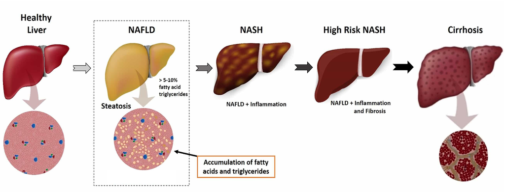

# Relationships between NAFLD and other disease

- NAFLD is strongly associated with obesity, diabetes, CVD[^3]
- Drastically increased in patient groups with these diseases

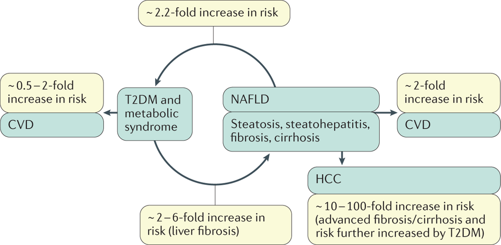

# Mechanisms of NAFLD development and therapeutic strategies

**Management strategies (lifestyle interventions)**

- weight loss
- healthier life style habits (physical exercises, diet etc.)

**Molecular aspects (heterogeneous):**

- many molecular pathways that contribute to the development of NAFLD
- pathogenic drivers are not likely to be identical among all patients

**There are still no approved pharmacological therapies for NAFLD!!**[^4]

# Aim & Method

- investigate the molecular mechanisms underlying NAFLD progression

**RNA sequencing data**[^5]

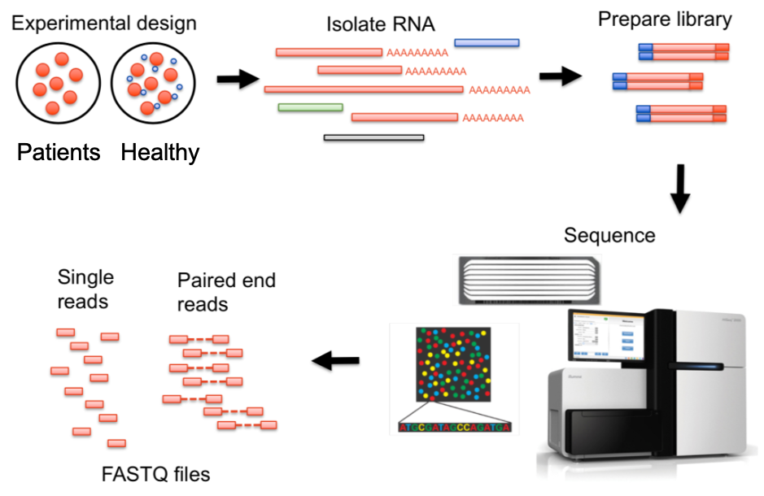

# Basic analysis and advanced analysis

- Raw sequencing reads in fastq format
- Mapped to the genome using alignment software
- Summarise reads over genes to generate a count table
- Determine differentially expressed genes using R
- Exploratory analyses: pathway enrichment and disease association analysis

# Data

- Public datasets shared by other study[^6] and metadata can be found from GEO

GSE135251

- fastq files can be found in ENA database based on its projectID

[PRJNA558102](https://www.ebi.ac.uk/ena/browser/view/PRJNA558102?show=reads)

# Preparation

Software need to be installed on PC:

- R (https://ftpmirror1.infania.net/mirror/CRAN/)
- Rstudio (https://www.rstudio.com/products/rstudio/)
- Filezila (https://filezilla-project.org/)
- putty (https://www.chiark.greenend.org.uk/~sgtatham/putty/latest.html) only if you are using windows
[^1]: Pharmacological Reports volume 72, pages1–12 (2020)
[^2]: Nature Reviews Gastroenterology & Hepatology volume 18, pages223–238 (2021)
[^3]: Nature Reviews Gastroenterology & Hepatology volume 18, pages24–39 (2021)
[^4]: Nature Medicine volume 24, pages908–922 (2018)
[^5]: Nature Reviews Genetics volume 20, pages631–656 (2019)
[^6]: Sci Transl Med 2020 Dec 2;12(572)